# Homework 6

*This week we learnt about analysing longitudinal data.*

```r
date()
```

```
## [1] "Thu Dec 03 22:15:11 2020"
```

```r
#Loading the data

RATSL <- read.table("~/IODS-project/data/RATSL.txt", sep="\t")
BPRSL <- read.table("~/IODS-project/data/BPRSL.txt", sep="\t")

#Also loading the original RATS data
RATS <- read.table("https://raw.githubusercontent.com/KimmoVehkalahti/MABS/master/Examples/data/rats.txt",
                   sep  = "\t", header = T)

#Accessing libraries

library(dplyr)
library(dplyr)
library(ggplot2)
library(lme4)
```

# 1) RATSL data

I will implement the analyses of Chapter 8 in the MABS book, using the RATSL data set. This is a longitudinal data set of rats in three different diet treatments. Each rat was measured several times during the 64 days of the study. In the analysis below, we mostly ignore the correlated nature of the data.

```r
str(RATSL)
```

```
## 'data.frame':    176 obs. of  5 variables:
##  $ ID    : int  1 2 3 4 5 6 7 8 9 10 ...
##  $ Group : int  1 1 1 1 1 1 1 1 2 2 ...
##  $ WD    : Factor w/ 11 levels "WD1","WD15","WD22",..: 1 1 1 1 1 1 1 1 1 1 ...
##  $ Weight: int  240 225 245 260 255 260 275 245 410 405 ...
##  $ Time  : int  1 1 1 1 1 1 1 1 1 1 ...
```

```r
#Changing ID and Group to factors
RATSL$ID <- factor(RATSL$ID)
RATSL$Group <- factor(RATSL$Group)

str(RATSL)
```

```
## 'data.frame':    176 obs. of  5 variables:
##  $ ID    : Factor w/ 16 levels "1","2","3","4",..: 1 2 3 4 5 6 7 8 9 10 ...
##  $ Group : Factor w/ 3 levels "1","2","3": 1 1 1 1 1 1 1 1 2 2 ...
##  $ WD    : Factor w/ 11 levels "WD1","WD15","WD22",..: 1 1 1 1 1 1 1 1 1 1 ...
##  $ Weight: int  240 225 245 260 255 260 275 245 410 405 ...
##  $ Time  : int  1 1 1 1 1 1 1 1 1 1 ...
```

**Description:**_ The RATSL data set consists of 176 observations and 5 variables. The data are body weights of rats, recorded over a 9-week period. The 16 studied rats were split to three different diet treatments, to study whether they affect the rats’ growth profiles.

Next, let’s plot the weight of all studied rats, differentiating between the treatment groups.

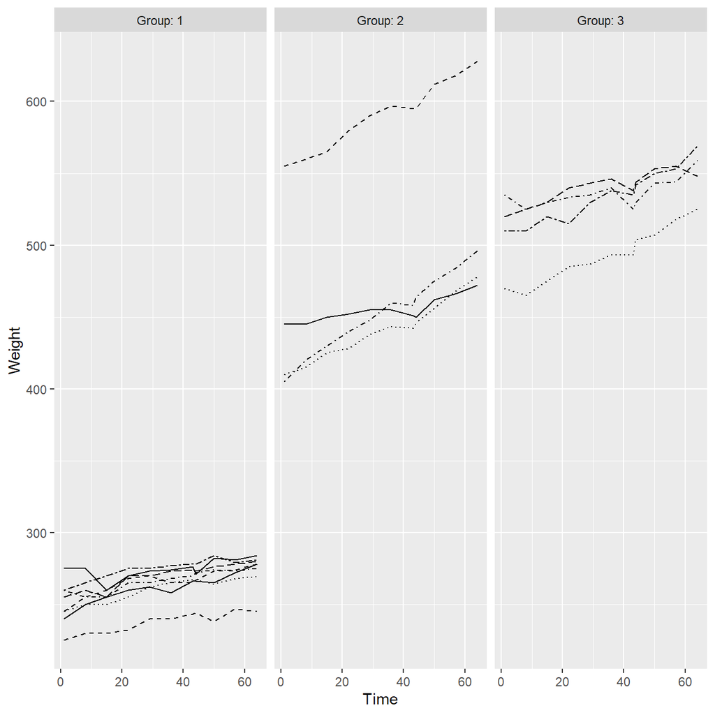

```r
#Drawing the plot
ggplot(RATSL, aes(x = Time, y = Weight, linetype = ID)) +
  geom_line() +
  scale_linetype_manual(values = rep(1:10, times=4)) +
  facet_grid(. ~ Group, labeller = label_both) +
  theme(legend.position = "none") +
  scale_y_continuous(limits = c(min(RATSL$Weight), max(RATSL$Weight)))
```

**Description:**_ Each line in the plot is an individual rat. We can see that the weight of individuals in all treatment groups seems to increase over time. However, treatment group 1 really stands out by having the lightest individuals and lowest variation among individuals.

Let’s take a look at standardized values of each observation (below). This means checking if heavier rats at the beginning tend to be heavier throughout the study or not.

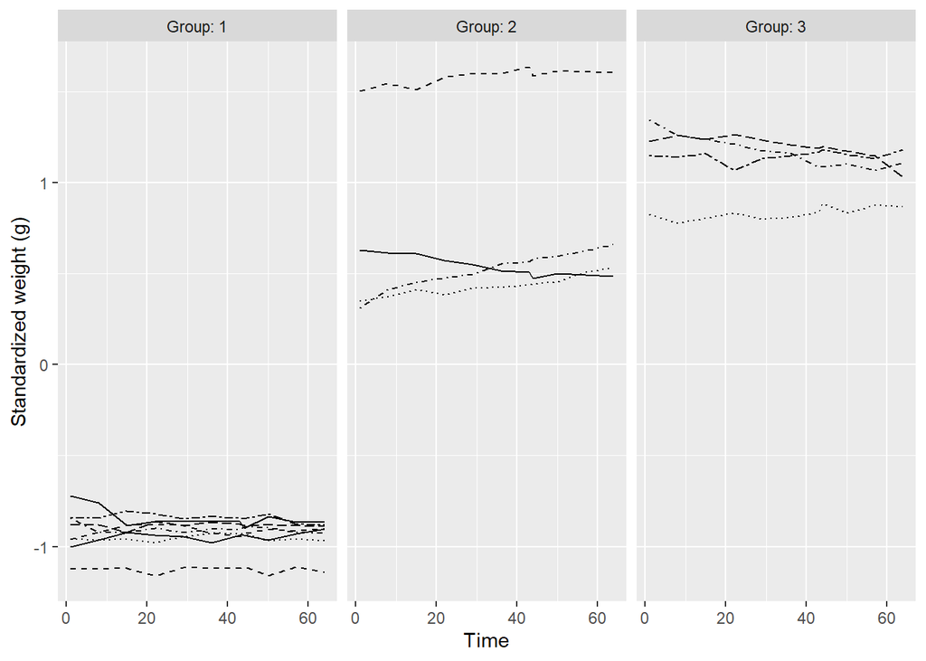

```r
#Standardizing the variable Weight
RATSL <- RATSL %>% group_by(Time) %>%
  mutate(stdweight = (Weight - mean(Weight))/sd(Weight) ) %>%
  ungroup()

#Drawing the plot
ggplot(RATSL, aes(x = Time, y = stdweight, linetype = ID)) +
  geom_line() +
  scale_linetype_manual(values = rep(1:10, times=4)) +
  facet_grid(. ~ Group, labeller = label_both) +
  theme(legend.position = "none") +
  scale_y_continuous(name = "Standardized weight (g)")
```

**Description:**_ Again, each line is an individual rat. Now we actually see no increase (nor decrease) in individuals’ standardized weights over time.

Next, I will plot the mean response profiles for the three diet treatment groups.

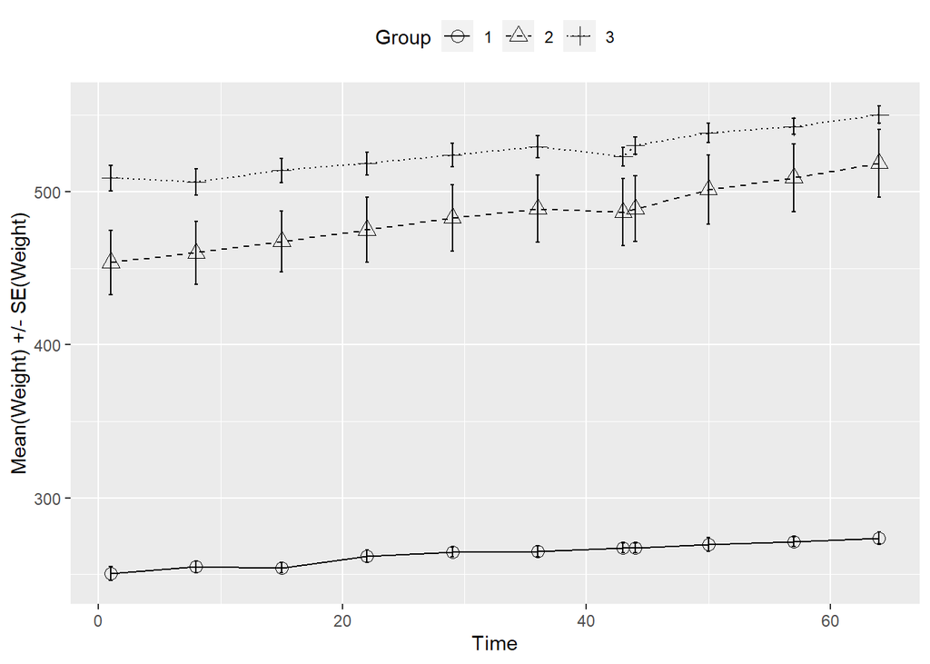

```r
#Number of days, baseline (day 1) included
n <- RATSL$Time %>% unique() %>% length()

#Summary data with mean and standard error of Weight by treatment and week
RATSS <- RATSL %>%
  group_by(Group, Time) %>%
  summarise(mean = mean(Weight), se = (sd(Weight)/sqrt(n)) ) %>%
  ungroup()

#Plotting the mean profiles
ggplot(RATSS, aes(x = Time, y = mean, linetype = Group, shape = Group)) +
  geom_line() +
  scale_linetype_manual(values = c(1,2,3)) +
  geom_point(size=3) +
  scale_shape_manual(values = c(1,2,3)) +
  geom_errorbar(aes(ymin=mean-se, ymax=mean+se, linetype="1"), width=0.3) +
  theme(legend.position = c(0.8,0.8,0.8)) + theme(legend.position = "top") +
  scale_y_continuous(name = "Mean(Weight) +/- SE(Weight)")
```

**Description:**_ The plot shows how the mean weight of rats seems to increase over time in all three treatment groups. Again, Group 1 is shown to have the lightest rats by far. Group 3 has slightly heavier rats than Group 2. The error bars illustrate the standard error of the mean.

Next, I will hunt down the outliers in the data set.

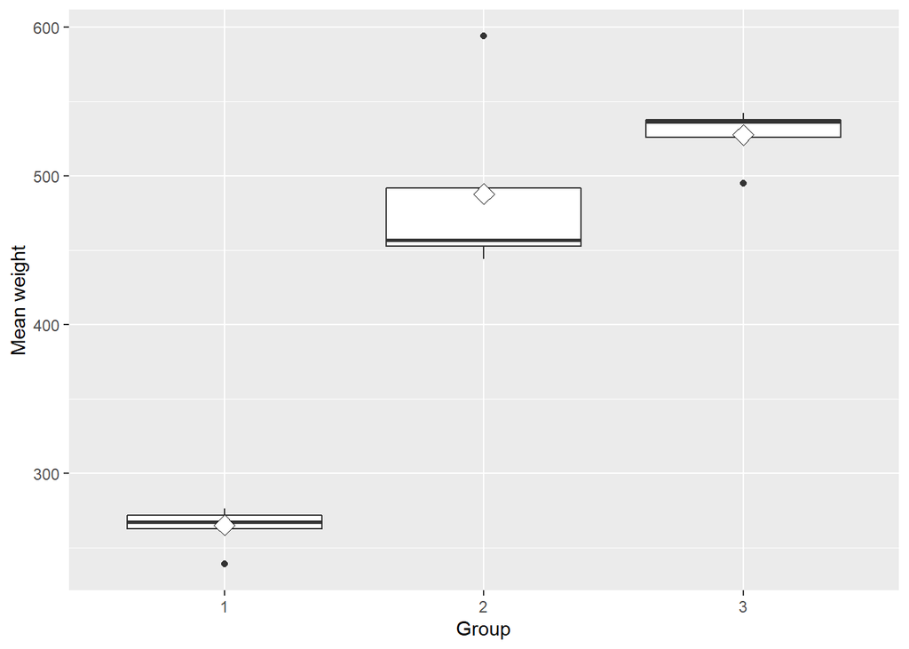

```r
#Creating a summary data by Group and ID with mean as the summary variable (ignoring baseline day 1)
RATSL8S <- RATSL %>%
  filter(Time > 1) %>%
  group_by(Group, ID) %>%
  summarise( mean=mean(Weight) ) %>%
  ungroup()

#Drawing a boxplot of the mean versus Group (treatment)
ggplot(RATSL8S, aes(x = Group, y = mean)) +
  geom_boxplot() +
  stat_summary(fun.y = "mean", geom = "point", shape=23, size=4, fill = "white") +
  scale_y_continuous(name = "Mean weight")
```

*Description:* We can see that there are three outliers - one in each treatment group. I’ll find them and remove them (below).

```r
#We can see tha the outliers are the smallest values in Groups 1 & 3, and highest value in Group 2. Let's see what the values are, and check which individuals the values correspond to.

min(RATSL8S[RATSL8S$Group == "1", 3])
```

```
## [1] 238.9
```

```r
max(RATSL8S[RATSL8S$Group == "2", 3])
```

```
## [1] 594
```

```r
min(RATSL8S[RATSL8S$Group == "3", 3])
```

```
## [1] 495.2
```

```r
#Checking which rows these values are on:
print(RATSL8S)
```

```
## # A tibble: 16 x 3
##    Group ID     mean
##    <fct> <fct> <dbl>
##  1 1     1      263.
##  2 1     2      239.
##  3 1     3      262.
##  4 1     4      267.
##  5 1     5      271.
##  6 1     6      276.
##  7 1     7      275.
##  8 1     8      268.
##  9 2     9      444.
## 10 2     10     458.
## 11 2     11     456.
## 12 2     12     594
## 13 3     13     495.
## 14 3     14     536.
## 15 3     15     542.
## 16 3     16     536.
```

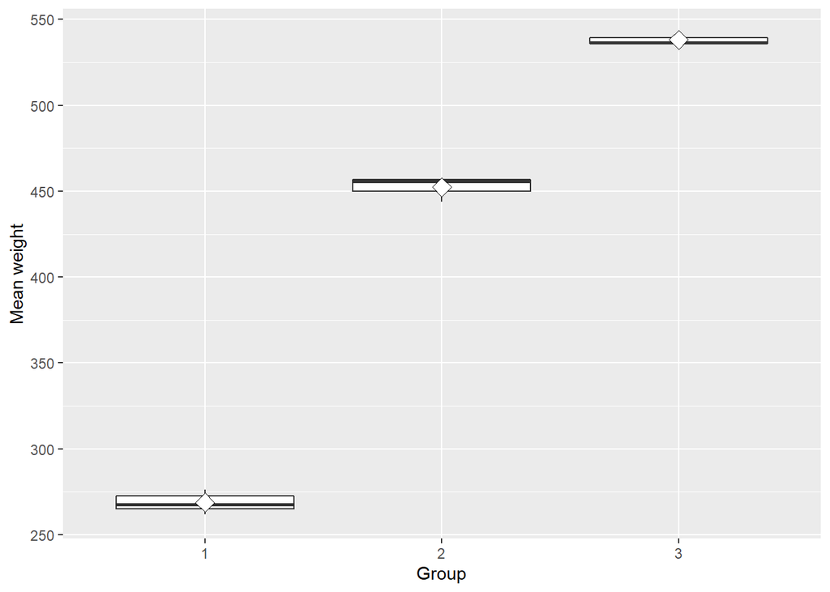

```r
#The outliers are on rows 2, 12 and 13

#Filtering the outliers
RATSL8S1 <- RATSL8S %>%
  filter(ID != 2 & ID != 12 & ID != 13)

#Drawing a boxplot of the mean versus treatment, outliers removed
ggplot(RATSL8S1, aes(x = Group, y = mean)) +
  geom_boxplot() +
  stat_summary(fun.y = "mean", geom = "point", shape=23, size=4, fill = "white") +
  scale_y_continuous(name = "Mean weight")
```

**Description:**_ The difference between Groups 2 and 3 is much more pronounced without the outliers. So, it seems quite clear that Group 3 has the heaviest rats, and Group 1 the lightest.

Next, I will statistically test if the groups differ. First, I will add the baseline (day 1) as a new variable to the summary data. This might be useful because baseline measurements in a longitudinal study like this are often correlated with the summary measure. Using the baseline weight here as a covariate might improve the precision of the model.

```r
#Adding the baseline
RATSL8S2 <- RATSL8S %>%
  mutate(baseline = RATS$WD1)

#Fitting the linear model with the mean as the response
fit <- lm(mean ~ baseline + Group, data = RATSL8S2)

#Checking the summary statistics for this model
summary(fit)
```

```
##
## Call:
## lm(formula = mean ~ baseline + Group, data = RATSL8S2)
##
## Residuals:
##     Min      1Q  Median      3Q     Max
## -23.905  -4.194   2.190   7.577  14.800
##
## Coefficients:
##             Estimate Std. Error t value Pr(>|t|)
## (Intercept) 33.16375   21.87657   1.516   0.1554
## baseline     0.92513    0.08572  10.793 1.56e-07 ***
## Group2      34.85753   18.82308   1.852   0.0888 .
## Group3      23.67526   23.25324   1.018   0.3287
## ---
## Signif. codes:  0 '***' 0.001 '**' 0.01 '*' 0.05 '.' 0.1 ' ' 1
##
## Residual standard error: 11.68 on 12 degrees of freedom
## Multiple R-squared:  0.9936, Adjusted R-squared:  0.992
## F-statistic: 622.1 on 3 and 12 DF,  p-value: 1.989e-13
```

```r
#Computing the analysis of variance (ANOVA) table for the fitted model
anova(fit)
```

```
## Analysis of Variance Table
##
## Response: mean
##           Df Sum Sq Mean Sq   F value   Pr(>F)
## baseline   1 253625  253625 1859.8201 1.57e-14 ***
## Group      2    879     439    3.2219  0.07586 .
## Residuals 12   1636     136
## ---
## Signif. codes:  0 '***' 0.001 '**' 0.01 '*' 0.05 '.' 0.1 ' ' 1
```

**Description:**_ The ANOVA result shows that baseline weight does have a very significant effect on the mean weight of rats in this study. Interestingly, the effect of the treatment (Group) does not have a significant effect on the mean weight. The group effect is very significant, when excluding the baseline information (analysis not shown here). Therefore, adding the baseline weight as a covariate definitely helped construct a better model to explain the data.

# 2) BPRSL data

I will implement the analyses of Chapter 9 in the MABS book, using the BPRSL data set. This is another longitudinal data set, consisting of 40 study subjects who were randomly assigned to two treatment groups, and rated on the “brief psychiatric rating scale” (BPRS) before and during the treatment. The treatment lasted eight weeks.

The BPRS is used to evaluate patients who are suspected to have schizophrenia. A high score indicates severe symptoms, such hostility, suspiciousness and hallucinations.

```r
str(BPRSL)
```

```
## 'data.frame':    360 obs. of  5 variables:
##  $ treatment: int  1 1 1 1 1 1 1 1 1 1 ...
##  $ subject  : int  1 2 3 4 5 6 7 8 9 10 ...
##  $ weeks    : Factor w/ 9 levels "week0","week1",..: 1 1 1 1 1 1 1 1 1 1 ...
##  $ bprs     : int  42 58 54 55 72 48 71 30 41 57 ...
##  $ week     : int  0 0 0 0 0 0 0 0 0 0 ...
```

```r
#Changing ID and Group to factors
BPRSL$subject <- factor(BPRSL$subject)
BPRSL$treatment <- factor(BPRSL$treatment)

str(BPRSL)
```

```
## 'data.frame':    360 obs. of  5 variables:
##  $ treatment: Factor w/ 2 levels "1","2": 1 1 1 1 1 1 1 1 1 1 ...
##  $ subject  : Factor w/ 20 levels "1","2","3","4",..: 1 2 3 4 5 6 7 8 9 10 ...
##  $ weeks    : Factor w/ 9 levels "week0","week1",..: 1 1 1 1 1 1 1 1 1 1 ...
##  $ bprs     : int  42 58 54 55 72 48 71 30 41 57 ...
##  $ week     : int  0 0 0 0 0 0 0 0 0 0 ...
```

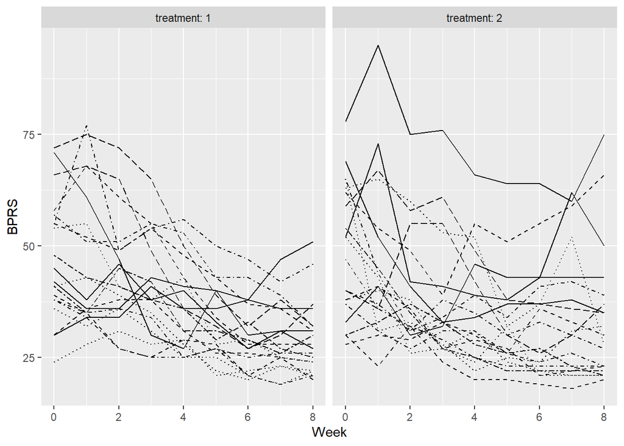

```r
#Plotting the BPRSL data
ggplot(BPRSL, aes(x = week, y = bprs, linetype = subject)) +
  geom_line() +
  scale_linetype_manual(values = rep(1:10, times=4)) +
  facet_grid(. ~ treatment, labeller = label_both) +
  theme(legend.position = "none") +
  scale_y_continuous(name = "BPRS", limits = c(min(BPRSL$bprs), max(BPRSL$bprs))) +
  scale_x_continuous(name = "Week", limits = c(min(BPRSL$week), max(BPRSL$week)))
```

**Description:** Each line in the plot is an individual study subject (one of the 40 men in the study). This seems to show that the BPRS value decreased for most individuals during the study. From this plot alone it is not clear to me if there is any difference between the treatment groups.

Next, I will continue to ignore that the data set consists of repeatedly measured individuals, and fit a multiple linear regression model with bprs as the response, and week & treatment as the explanatory variables.

```r
#Creating a regression model
BPRS_reg <- lm(bprs ~ week + treatment, data = BPRSL)

#Printing out a summary of the model
summary(BPRS_reg)
```

```
##
## Call:
## lm(formula = bprs ~ week + treatment, data = BPRSL)
##
## Residuals:
##     Min      1Q  Median      3Q     Max
## -22.454  -8.965  -3.196   7.002  50.244
##
## Coefficients:
##             Estimate Std. Error t value Pr(>|t|)
## (Intercept)  46.4539     1.3670  33.982   <2e-16 ***
## week         -2.2704     0.2524  -8.995   <2e-16 ***
## treatment2    0.5722     1.3034   0.439    0.661
## ---
## Signif. codes:  0 '***' 0.001 '**' 0.01 '*' 0.05 '.' 0.1 ' ' 1
##
## Residual standard error: 12.37 on 357 degrees of freedom
## Multiple R-squared:  0.1851, Adjusted R-squared:  0.1806
## F-statistic: 40.55 on 2 and 357 DF,  p-value: < 2.2e-16
```

**Description:** The regression model shows that there is no statistically significant difference between the treatments, but a strong difference between weeks. In this case, the BPRS values are decreasing over time (weeks).

Next, let’s see a random intercept model that allows the linear regression fit for each study subject to differ in intercept, compared to other subjects.

```r
#Creating a random intercept model
BPRS_ref <- lmer(bprs ~ week + treatment + (1 | subject), data = BPRSL, REML = FALSE)

#Summary of the model
summary(BPRS_ref)
```

```
## Linear mixed model fit by maximum likelihood  ['lmerMod']
## Formula: bprs ~ week + treatment + (1 | subject)
##    Data: BPRSL
##
##      AIC      BIC   logLik deviance df.resid
##   2748.7   2768.1  -1369.4   2738.7      355
##
## Scaled residuals:
##     Min      1Q  Median      3Q     Max
## -3.0481 -0.6749 -0.1361  0.4813  3.4855
##
## Random effects:
##  Groups   Name        Variance Std.Dev.
##  subject  (Intercept)  47.41    6.885
##  Residual             104.21   10.208
## Number of obs: 360, groups:  subject, 20
##
## Fixed effects:
##             Estimate Std. Error t value
## (Intercept)  46.4539     1.9090  24.334
## week         -2.2704     0.2084 -10.896
## treatment2    0.5722     1.0761   0.532
##
## Correlation of Fixed Effects:
##            (Intr) week
## week       -0.437
## treatment2 -0.282  0.000
```

**Description:** The fairly high standard deviation of ‘subject’ indicates fairly high variability in intercept between study subjects.

Next, let’s see a random intercept and random slope model. Fitting one allows the linear regression fits for each individual to differ in intercept but also in slope. This way we can account for individual differences in the study subjects’ BPRS development, and also the effect of time.

```r
#Creating a random intercept and random slope model
BPRS_ref1 <- lmer(bprs ~ week + treatment + (week | subject), data = BPRSL, REML = FALSE)

#Summary of the model
summary(BPRS_ref1)
```

```
## Linear mixed model fit by maximum likelihood  ['lmerMod']
## Formula: bprs ~ week + treatment + (week | subject)
##    Data: BPRSL
##
##      AIC      BIC   logLik deviance df.resid
##   2745.4   2772.6  -1365.7   2731.4      353
##
## Scaled residuals:
##     Min      1Q  Median      3Q     Max
## -2.8919 -0.6194 -0.0691  0.5531  3.7976
##
## Random effects:
##  Groups   Name        Variance Std.Dev. Corr
##  subject  (Intercept) 64.8222  8.0512
##           week         0.9609  0.9802   -0.51
##  Residual             97.4305  9.8707
## Number of obs: 360, groups:  subject, 20
##
## Fixed effects:
##             Estimate Std. Error t value
## (Intercept)  46.4539     2.1052  22.066
## week         -2.2704     0.2977  -7.626
## treatment2    0.5722     1.0405   0.550
##
## Correlation of Fixed Effects:
##            (Intr) week
## week       -0.582
## treatment2 -0.247  0.000
```

```r
#ANOVA test on this and the previous model
anova(BPRS_ref1, BPRS_ref)
```

```
## Data: BPRSL
## Models:
## BPRS_ref: bprs ~ week + treatment + (1 | subject)
## BPRS_ref1: bprs ~ week + treatment + (week | subject)
##           npar    AIC    BIC  logLik deviance  Chisq Df Pr(>Chisq)
## BPRS_ref     5 2748.7 2768.1 -1369.4   2738.7
## BPRS_ref1    7 2745.4 2772.6 -1365.7   2731.4 7.2721  2    0.02636 *
## ---
## Signif. codes:  0 '***' 0.001 '**' 0.01 '*' 0.05 '.' 0.1 ' ' 1
```

**Description:** The ANOVA test shows that the new model is significantly better than the previous one. Nice.

Finally, let’s see if there is an interaction between treatment and time, that should be taken into account.

```r
#Creating a random intercept and random slope model with the interaction
BPRS_ref2 <- lmer(bprs ~ week * treatment + (week | subject), data = BPRSL, REML = FALSE)

#Summary of the model
summary(BPRS_ref2)
```

```
## Linear mixed model fit by maximum likelihood  ['lmerMod']
## Formula: bprs ~ week * treatment + (week | subject)
##    Data: BPRSL
##
##      AIC      BIC   logLik deviance df.resid
##   2744.3   2775.4  -1364.1   2728.3      352
##
## Scaled residuals:
##     Min      1Q  Median      3Q     Max
## -3.0512 -0.6271 -0.0768  0.5288  3.9260
##
## Random effects:
##  Groups   Name        Variance Std.Dev. Corr
##  subject  (Intercept) 64.9964  8.0620
##           week         0.9687  0.9842   -0.51
##  Residual             96.4707  9.8220
## Number of obs: 360, groups:  subject, 20
##
## Fixed effects:
##                 Estimate Std. Error t value
## (Intercept)      47.8856     2.2521  21.262
## week             -2.6283     0.3589  -7.323
## treatment2       -2.2911     1.9090  -1.200
## week:treatment2   0.7158     0.4010   1.785
##
## Correlation of Fixed Effects:
##             (Intr) week   trtmn2
## week        -0.650
## treatment2  -0.424  0.469
## wek:trtmnt2  0.356 -0.559 -0.840
```

```r
#ANOVA test on this and the best model so far
anova(BPRS_ref2, BPRS_ref1)
```

```
## Data: BPRSL
## Models:
## BPRS_ref1: bprs ~ week + treatment + (week | subject)
## BPRS_ref2: bprs ~ week * treatment + (week | subject)
##           npar    AIC    BIC  logLik deviance  Chisq Df Pr(>Chisq)
## BPRS_ref1    7 2745.4 2772.6 -1365.7   2731.4
## BPRS_ref2    8 2744.3 2775.4 -1364.1   2728.3 3.1712  1    0.07495 .
## ---
## Signif. codes:  0 '***' 0.001 '**' 0.01 '*' 0.05 '.' 0.1 ' ' 1
```

*Description*: We can see that the interaction model is not significantly better, so there is no reason to use it.

As the last thing with this data set, I will plot the fitted values of BPRS.

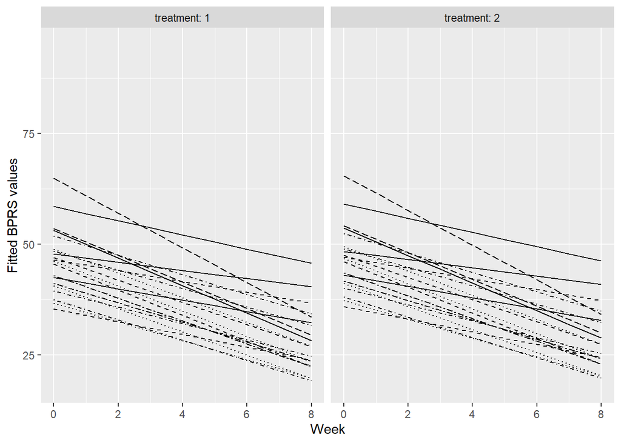

```r
#Creating a vector of the fitted values
FittedBPRS <- fitted(BPRS_ref1)

# Create a new column fitted to BPRSL
BPRSL <- mutate(BPRSL, fitted = FittedBPRS)

#Drawing the plot of BPRSL, with the Fitted values of bprs
ggplot(BPRSL, aes(x = week, y = fitted, linetype = subject)) +
  geom_line() +
  scale_linetype_manual(values = rep(1:10, times=4)) +
  facet_grid(. ~ treatment, labeller = label_both) +
  theme(legend.position = "none") +
  scale_y_continuous(name = "Fitted BPRS values", limits = c(min(BPRSL$bprs), max(BPRSL$bprs))) +
  scale_x_continuous(name="Week")
```

**Description:** Once again, this is not the nicest looking graph but hopefully does the job. It shows that while the response of study subjects to the treatment groups looks similar, both treatments are working. The BPRS values go down over time, indicating the study subjects have less/lighter psychiatric symptoms than in the beginning of the study.

This is the end of this last exercise :-)